# Do man and women write academic papers in a different way?

### Adding a third topic

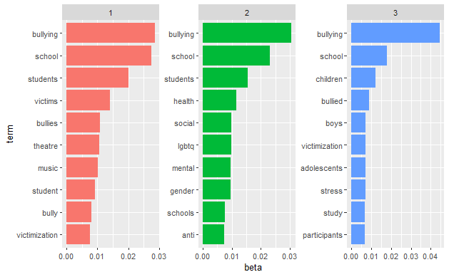

```r
lda<- LDA(dtm, k = 3, control = list(seed = 1234))

ap_3_topics <- tidy(lda, matrix = "beta")

ap_top_terms <- ap_3_topics |>
  group_by(topic) |>
  slice_max(beta, n = 10) |>
  ungroup() |>
  arrange(topic, -beta)

ap_top_terms |>
  mutate(term = reorder_within(term, beta, topic)) |>
  ggplot(aes(beta, term, fill = factor(topic))) +
  geom_col(show.legend = FALSE) +
  facet_wrap(~ topic, scales = "free") +
  scale_y_reordered()
```

Looking at the most probable words for each topic represantation we can say that:

- there is not much change in the topic 1 and 2, only some variation on the beta of some words.
- In the third topic (the blue one), we find terms like children, boys, victimization, adolescents, and stress, which suggest a more developmental or psychological framing of bullying. Unlike Topic 1, which highlights school context and activities, or Topic 2, which leans into identity and systemic concerns, Topic 3 appears to focus more on age, gender dynamics among youth, emotional stress, and behavioral outcomes. But we have to highlight the fact that the majority of the most significant words have a beta score of < 0.01 suggesting that this topic could be a recipient of the essays that do not fit perfectly in the first two topics.

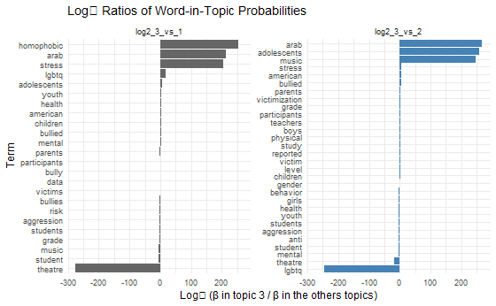

```r
beta_wide <- ap_3_topics |>
  mutate(topic = paste0("topic", topic)) |>
  pivot_wider(names_from = topic, values_from = beta) |>
  # keep only words that appear with beta > .001 in at least one topic
  filter(topic1 >  .005 |
         topic2 >  .005 |
         topic3 >  .005)

beta_long <- beta_wide |>
  # compute two log-ratios vs. Topic 1
  mutate(
    log2_3_vs_2 = log2(topic3 / topic2),
    log2_3_vs_1 = log2(topic3 / topic1)
  ) |>
  pivot_longer(
    cols      = starts_with("log2_"),
    names_to  = "comparison",
    values_to = "log_ratio"
  ) |>
  # only show terms with a strong log-ratio effect
  filter(abs(log_ratio) >= 1)

ggplot(beta_long,
       aes(x = log_ratio,
           y = reorder_within(term, log_ratio, comparison),
           fill = comparison)) +
  geom_col(show.legend = FALSE) +
  facet_wrap(~ comparison,
             scales = "free_y",
             labeller = labeller(
               log2_3_vs_2 = "Topic 3 vs Topic 2",
               log2_3_vs_1 = "Topic 3 vs Topic 1"
             )) +
  scale_y_reordered() +
  scale_fill_manual(values = c(
    log2_3_vs_2 = "steelblue",
    log2_3_vs_1 = "gray40"
  )) +
  labs(
    title = "Log₂ Ratios of Word-in-Topic Probabilities",
    x     = "Log₂ (β in topic 3 / β in the others topics)",
    y     = "Term"
  ) +
  theme_minimal()
```

This graph allows us to clearly compare the log ratios of word probabilities (beta) between Topic 3 and Topic 1 (left panel), and Topic 3 and Topic 2 (right panel) in our model.

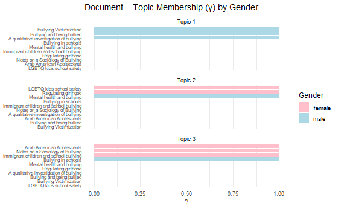

```r
ap_documents <- tidy(lda, matrix = "gamma") |>
  left_join(gender_lookup, by = c("document" = "essay"))

ap_documents |>
  mutate(doc_reorder = reorder_within(document, gamma, topic)) %>%
  ggplot(aes(x = gamma, y = doc_reorder, fill = Gender)) +
    geom_col(show.legend = TRUE) +
    scale_fill_manual(values = c(female = "pink", male = "lightblue")) +
    facet_wrap(~ topic, scales = "free_y", ncol = 1,
               labeller = labeller(topic = c(`1`="Topic 1", `2`="Topic 2", `3`="Topic 3" ))) +
    scale_y_reordered() +
    labs(
      x = expression(gamma),
      y = NULL,
      fill = "Gender",
      title = "Document – Topic Membership (γ) by Gender"
    ) +
    theme_minimal() +
    theme(
      panel.grid.major.y = element_blank(),
      axis.text.y = element_text(size = 8)
    )
```

### Summary

This study analyzed essays written by male and female authors, focusing on thematic patterns, word associations, and sentiment differences.

2.TF-IDF Bigram Analysis

-In female essays, high TF-IDF bigrams included “unrecognized bullying”, “homophobic bullying”, and “girl bullying”, highlighting attention to marginalized identities.

-In male essays, frequent bigrams were “mental health”, “bully victim”, and “band choir orchestra”, reflecting psychological and extracurricular concerns.

3.Sentiment and Negation Analysis

-Female authors often used negated sentiment expressions like “not want”, “not happy”, and “not like”, with both positive and negative emotional effects.

-Male authors used negations like “not enjoy”, “not support”, and “not bully”, showing less emotional range and more factual tone.

4.Word Network and Correlation

-In female word networks, key clusters formed around bullying, gender, power, and school, showing tight associations with social issues like harassment, exclusion, and inequality.

-In male networks, clusters were more academic and data-driven, with strong links between mental health, diagnosis, probability, and academic status.

5. Topic Modeling (LDA) and Gendered Themes

-Topic 1 was characterized by words such as victims, bullies, theatre, music, and school. These terms suggest a school-centered, behavior-oriented perspective on bullying, grounded in student roles, experiences, and extracurricular settings.

-Topic 2, in contrast, was defined by terms like social, gender, LGBTQ, mental, and health. This points to an identity-based, sociologically-oriented discourse, emphasizing systemic and psychological dimensions of bullying.

-A clear gender division emerged: male-authored essays had higher γ-values for Topic 1, while female-authored essays clustered around Topic 2. Although we expected a more sharply defined split, this pattern supports our hypothesis that gendered authorship influences thematic emphasis.

-Further log-ratio analysis reinforced these insights. Words such as targeting, marginalization, sexuality, and inequality were far more prevalent in Topic 2, while Topic 1 featured terms like grades, arts, immigrant, and ensemble. This lexical divide reinforces the idea that Topic 1 reflects “bullying in practice” (contextual, behavioral), while Topic 2 represents “bullying in theory” (structural, identity-focused).